Bruce Cochrane

12/11/2016

# 1 Overview

This is just a foolaround file with the new RStudio shortcuts (available at file:///Applications/RStudio.app/Contents/Resources/www/docs/keyboard.htm).

1. Assignment - supposed to be option -, however only works in chunk
2. pipe operator - CmdSftM – %>% – works fine
3. output yaml can be modified by clicking on the gear wheel at the top of the editing pane, followed by output options
4. Note - under global options/rmarkdown, uncheck show chunk output inline to retain traditional RSTudio look

## 1.1 Some more detail

So I wonder if we could do this with the maps project - interesting possibilities

## 1.2 Some different material

Put in at this point just to see what a subheading would look like

# 2 Some basic analysis

First, we will generate some numbers, then we will plot it in a couple of ways:

```r
x <- rnorm(100,0,1)
```

By clicking on the tabs below, you can see the data visualized as either a conventional histogram, or as a “qqplot”, which is a good way to determine the extent to which observed data are explained by a normal distribution.

## 2.1 A histogram

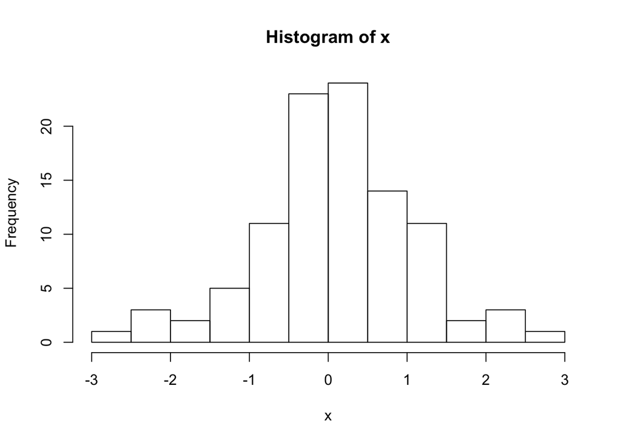

Figure 1. A Histogram of 100 Normally Distributed numbers with mean of zero and standard deviation of one

```r
hist(x)
```

## 2.2 A qqplot

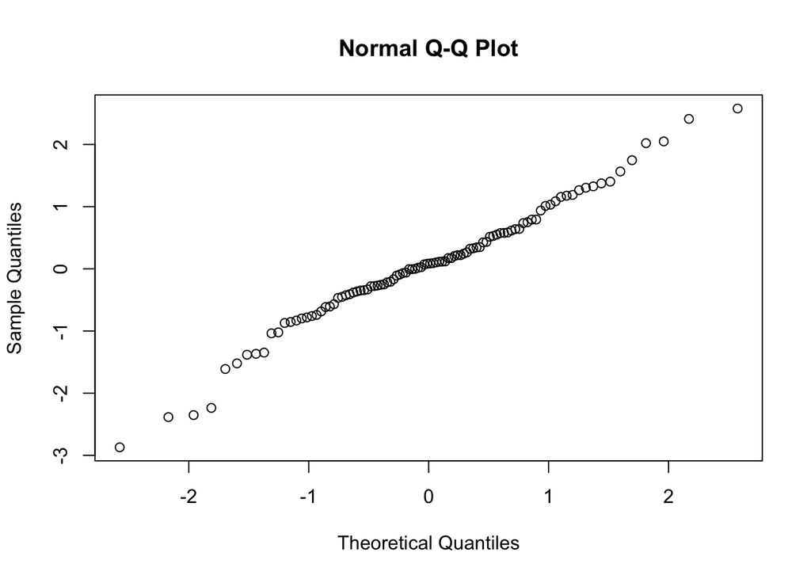

Figure 2. QQPlot, comparing the distribution of the data to that expected based on a normal distribution

```r
qqnorm(x)
```